# Automated Machine Learning Assignment

Shiyu Hua

#### Load the dataset

```python
import pandas as pd
path = 'C:/Users/lilyh/Desktop/final semester/5420/assignment3/'
df = pd.read_csv(path + 'XYZloan_default_selected_vars.csv') #, encoding = "ISO-8859-1")
df.head()
```

|  | Unnamed: 0.1 | Unnamed: 0 | id | loan_default | AP001 | AP002 | AP003 | AP004 | AP005 | AP006 | ... | CD162 | CD164 | CD166 | CD167 | CD169 | CD170 | CD172 | CD173 | MB005 | MB007 |
| --- | --- | --- | --- | --- | --- | --- | --- | --- | --- | --- | --- | --- | --- | --- | --- | --- | --- | --- | --- | --- | --- |
| 0 | 0 | 1 | 1 | 1 | 31 | 2 | 1 | 12 | 2017/7/6 10:21 | ios | ... | 13.0 | 13.0 | 0.0 | 0.0 | 1449.0 | 1449.0 | 2249.0 | 2249.0 | 7.0 | IPHONE7 |
| 1 | 1 | 2 | 2 | 0 | 27 | 1 | 1 | 12 | 2017/4/6 12:51 | h5 | ... | -99.0 | -99.0 | -99.0 | -99.0 | -99.0 | -99.0 | -99.0 | -99.0 | NaN | WEB |
| 2 | 2 | 3 | 3 | 0 | 33 | 1 | 4 | 12 | 2017/7/1 14:11 | h5 | ... | 3.0 | 2.0 | 33.0 | 0.0 | 33.0 | 0.0 | 143.0 | 110.0 | 8.0 | WEB |
| 3 | 3 | 4 | 4 | 0 | 34 | 2 | 4 | 12 | 2017/7/7 10:10 | android | ... | 0.0 | 0.0 | 0.0 | 0.0 | 0.0 | 0.0 | 0.0 | 0.0 | 10.0 | OPPO |
| 4 | 4 | 5 | 5 | 0 | 47 | 2 | 1 | 12 | 2017/7/6 14:37 | h5 | ... | -99.0 | -99.0 | -99.0 | -99.0 | -99.0 | -99.0 | -99.0 | -99.0 | NaN | WEB |

5 rows × 89 columns

```python
# check dimensions of the dataset, we found it has 80000 rows and 89 columns
print(df.shape)
print(df.columns) # check column names
```

```
(80000, 89)
Index(['Unnamed: 0.1', 'Unnamed: 0', 'id', 'loan_default', 'AP001', 'AP002',
       'AP003', 'AP004', 'AP005', 'AP006', 'AP007', 'AP008', 'AP009', 'TD001',
       'TD002', 'TD005', 'TD006', 'TD009', 'TD010', 'TD013', 'TD014', 'TD015',
       'TD022', 'TD023', 'TD024', 'TD025', 'TD026', 'TD027', 'TD028', 'TD029',
       'TD044', 'TD048', 'TD051', 'TD054', 'TD055', 'TD061', 'TD062', 'CR004',
       'CR005', 'CR009', 'CR012', 'CR015', 'CR017', 'CR018', 'CR019', 'PA022',
       'PA023', 'PA028', 'PA029', 'PA030', 'PA031', 'CD008', 'CD018', 'CD071',
       'CD072', 'CD088', 'CD100', 'CD101', 'CD106', 'CD107', 'CD108', 'CD113',
       'CD114', 'CD115', 'CD117', 'CD118', 'CD120', 'CD121', 'CD123', 'CD130',
       'CD131', 'CD132', 'CD133', 'CD135', 'CD136', 'CD137', 'CD152', 'CD153',
       'CD160', 'CD162', 'CD164', 'CD166', 'CD167', 'CD169', 'CD170', 'CD172',
       'CD173', 'MB005', 'MB007'],
      dtype='object')
```

#### Split train data and test data

```python
# split train and test, set test size to 0.3
from sklearn.model_selection import train_test_split
train, test = train_test_split(df, test_size = 0.3,random_state = 42)
```

```python
train.shape
```

```
(56000, 89)
```

```python
# feature transformation
var = pd.DataFrame(train.dtypes)
var = pd.DataFrame(train.dtypes).reset_index()
var.columns = ['varname','dtype']
var['source'] = var['varname'].str[:2]

# "AP004" is a bad data field and should be removed.
MB_list = list(var[var['source']=='MB']['varname'])
AP_list = list(var[(var['source']=='AP') & (var['varname']!='AP004') & (var['varname']!='AP005')]['varname'])
TD_list = list(var[var['source']=='TD']['varname'])
CR_list = list(var[var['source']=='CR']['varname'])
PA_list = list(var[var['source']=='PA']['varname'])
CD_list = list(var[var['source']=='CD']['varname'])
```

#### Run previous H2O Random Forest Model

- learn top variable importance

```python
#!pip install h2o
import h2o
h2o.init()
```

```
Checking whether there is an H2O instance running at http://localhost:54321 . connected.
```

[output not shown]

#### model with entire dataset

```python
# create entire dataset
train_hex = h2o.H2OFrame(train)
test_hex = h2o.H2OFrame(test)
predictors = CR_list + AP_list + MB_list + CR_list + PA_list +TD_list
target='loan_default'
```

```
Parse progress: |████████████████████████████████████████████████████████████████| (done) 100%
Parse progress: |████████████████████████████████████████████████████████████████| (done) 100%
```

```python
from h2o.estimators.random_forest import H2ORandomForestEstimator
rf_v1 = H2ORandomForestEstimator(
        model_id = 'rf_v1',
        ntrees = 300,
        nfolds=10,
        min_rows=100,
        seed=1234)
rf_v1.train(predictors,target,training_frame=train_hex)
```

```
drf Model Build progress: |██████████████████████████████████████████████████████| (done) 100%
Model Details
=============
H2ORandomForestEstimator :  Distributed Random Forest
Model Key:  rf_v1


Model Summary:
```

|  |  | number_of_trees | number_of_internal_trees | model_size_in_bytes | min_depth | max_depth | mean_depth | min_leaves | max_leaves | mean_leaves |
| --- | --- | --- | --- | --- | --- | --- | --- | --- | --- | --- |
| 0 |  | 300.0 | 300.0 | 1120206.0 | 13.0 | 20.0 | 15.506667 | 252.0 | 274.0 | 262.52667 |

```
ModelMetricsRegression: drf
** Reported on train data. **

MSE: 0.14788493836434066
RMSE: 0.3845581079165289
MAE: 0.2969888028471018
RMSLE: 0.2696060418954895
Mean Residual Deviance: 0.14788493836434066

ModelMetricsRegression: drf
** Reported on cross-validation data. **

MSE: 0.14800550026259662
RMSE: 0.3847148297929216
MAE: 0.29721432565292805
RMSLE: 0.26972343649256664
Mean Residual Deviance: 0.14800550026259662

Cross-Validation Metrics Summary:
```

|  |  | mean | sd | cv_1_valid | cv_2_valid | cv_3_valid | cv_4_valid | cv_5_valid | cv_6_valid | cv_7_valid | cv_8_valid | cv_9_valid | cv_10_valid |
| --- | --- | --- | --- | --- | --- | --- | --- | --- | --- | --- | --- | --- | --- |
| 0 | mae | 0.297218 | 0.001866 | 0.300624 | 0.295648 | 0.297143 | 0.296315 | 0.296358 | 0.296113 | 0.296999 | 0.296946 | 0.295459 | 0.300575 |
| 1 | mean_residual_deviance | 0.148008 | 0.001941 | 0.151563 | 0.147551 | 0.147063 | 0.147174 | 0.147584 | 0.147021 | 0.147446 | 0.148227 | 0.145234 | 0.151213 |
| 2 | mse | 0.148008 | 0.001941 | 0.151563 | 0.147551 | 0.147063 | 0.147174 | 0.147584 | 0.147021 | 0.147446 | 0.148227 | 0.145234 | 0.151213 |
| 3 | r2 | 0.050495 | 0.006095 | 0.049641 | 0.043484 | 0.047609 | 0.048088 | 0.049918 | 0.052442 | 0.047933 | 0.056902 | 0.064137 | 0.044797 |
| 4 | residual_deviance | 0.148008 | 0.001941 | 0.151563 | 0.147551 | 0.147063 | 0.147174 | 0.147584 | 0.147021 | 0.147446 | 0.148227 | 0.145234 | 0.151213 |
| 5 | rmse | 0.384710 | 0.002517 | 0.389312 | 0.384123 | 0.383488 | 0.383632 | 0.384167 | 0.383433 | 0.383988 | 0.385002 | 0.381096 | 0.388862 |
| 6 | rmsle | 0.269721 | 0.001498 | 0.272183 | 0.269502 | 0.269451 | 0.269280 | 0.269307 | 0.268934 | 0.269566 | 0.269451 | 0.267223 | 0.272309 |

```
Scoring History:
```

|  |  | timestamp | duration | number_of_trees | training_rmse | training_mae | training_deviance |
| --- | --- | --- | --- | --- | --- | --- | --- |
| 0 |  | 2022-08-03 22:02:08 | 4 min 29.968 sec | 0.0 | NaN | NaN | NaN |
| 1 |  | 2022-08-03 22:02:08 | 4 min 30.065 sec | 1.0 | 0.394567 | 0.297667 | 0.155683 |
| 2 |  | 2022-08-03 22:02:08 | 4 min 30.150 sec | 2.0 | 0.392094 | 0.296426 | 0.153738 |
| 3 |  | 2022-08-03 22:02:08 | 4 min 30.231 sec | 3.0 | 0.390498 | 0.296552 | 0.152489 |
| 4 |  | 2022-08-03 22:02:08 | 4 min 30.314 sec | 4.0 | 0.389778 | 0.296379 | 0.151927 |
| 5 |  | 2022-08-03 22:02:08 | 4 min 30.396 sec | 5.0 | 0.390021 | 0.296950 | 0.152117 |
| 6 |  | 2022-08-03 22:02:08 | 4 min 30.482 sec | 6.0 | 0.389264 | 0.296910 | 0.151526 |
| 7 |  | 2022-08-03 22:02:08 | 4 min 30.567 sec | 7.0 | 0.388863 | 0.297248 | 0.151214 |
| 8 |  | 2022-08-03 22:02:08 | 4 min 30.647 sec | 8.0 | 0.388109 | 0.296954 | 0.150629 |
| 9 |  | 2022-08-03 22:02:08 | 4 min 30.724 sec | 9.0 | 0.387716 | 0.297091 | 0.150324 |
| 10 |  | 2022-08-03 22:02:08 | 4 min 30.806 sec | 10.0 | 0.387100 | 0.296914 | 0.149847 |
| 11 |  | 2022-08-03 22:02:08 | 4 min 30.891 sec | 11.0 | 0.386828 | 0.296758 | 0.149636 |
| 12 |  | 2022-08-03 22:02:09 | 4 min 30.974 sec | 12.0 | 0.386606 | 0.296776 | 0.149464 |
| 13 |  | 2022-08-03 22:02:09 | 4 min 31.067 sec | 13.0 | 0.386408 | 0.296806 | 0.149311 |
| 14 |  | 2022-08-03 22:02:09 | 4 min 31.147 sec | 14.0 | 0.386306 | 0.296742 | 0.149233 |
| 15 |  | 2022-08-03 22:02:09 | 4 min 31.238 sec | 15.0 | 0.386137 | 0.296741 | 0.149102 |
| 16 |  | 2022-08-03 22:02:09 | 4 min 31.326 sec | 16.0 | 0.385986 | 0.296769 | 0.148985 |
| 17 |  | 2022-08-03 22:02:09 | 4 min 31.413 sec | 17.0 | 0.385867 | 0.296717 | 0.148893 |
| 18 |  | 2022-08-03 22:02:09 | 4 min 31.495 sec | 18.0 | 0.385701 | 0.296589 | 0.148766 |
| 19 |  | 2022-08-03 22:02:09 | 4 min 31.581 sec | 19.0 | 0.385618 | 0.296503 | 0.148702 |

```
See the whole table with table.as_data_frame()

Variable Importances:
```

|  | variable | relative_importance | scaled_importance | percentage |
| --- | --- | --- | --- | --- |
| 0 | TD013 | 20926.367188 | 1.000000 | 0.153756 |
| 1 | AP003 | 18561.025391 | 0.886968 | 0.136377 |
| 2 | TD009 | 15307.944336 | 0.731515 | 0.112475 |
| 3 | MB007 | 14486.244141 | 0.692248 | 0.106438 |
| 4 | TD005 | 9290.463867 | 0.443960 | 0.068262 |
| 5 | CR015 | 6468.123535 | 0.309090 | 0.047525 |
| 6 | TD014 | 5430.905762 | 0.259525 | 0.039904 |
| 7 | MB005 | 3528.454834 | 0.168613 | 0.025925 |
| 8 | TD010 | 2927.448486 | 0.139893 | 0.021509 |
| 9 | TD001 | 2867.679199 | 0.137037 | 0.021070 |
| 10 | AP001 | 2819.405273 | 0.134730 | 0.020716 |
| 11 | TD024 | 2523.056396 | 0.120568 | 0.018538 |
| 12 | TD023 | 2419.268799 | 0.115609 | 0.017776 |
| 13 | AP007 | 2392.086670 | 0.114310 | 0.017576 |
| 14 | PA028 | 2095.518066 | 0.100138 | 0.015397 |
| 15 | CR019 | 2039.156738 | 0.097444 | 0.014983 |
| 16 | AP008 | 2039.135620 | 0.097443 | 0.014983 |
| 17 | CR004 | 1988.247314 | 0.095012 | 0.014609 |
| 18 | CR017 | 1891.222046 | 0.090375 | 0.013896 |
| 19 | CR018 | 1886.654175 | 0.090157 | 0.013862 |

```
See the whole table with table.as_data_frame()
```

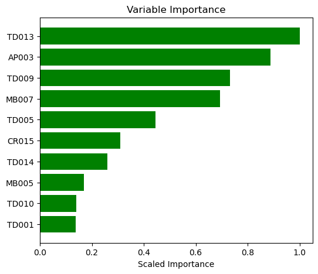

```python
def VarImp_top(model_name):

    import numpy as np
    from sklearn.metrics import roc_curve,auc
    from sklearn.metrics import average_precision_score
    from sklearn.metrics import precision_recall_curve
    import matplotlib.pyplot as plt

    # plot the variable importance
    plt.rcdefaults()
    variables = model_name._model_json['output']['variable_importances']['variable'][0:10]
    y_pos = np.arange(len(variables))
    fig, ax = plt.subplots(figsize = (6,len(variables)/2))
    scaled_importance = model_name._model_json['output']['variable_importances']['scaled_importance'][0:10]
    ax.barh(y_pos,scaled_importance,align='center',color='green')
    ax.set_yticks(y_pos)
    ax.set_yticklabels(variables)
    ax.invert_yaxis()
    ax.set_xlabel('Scaled Importance')
    ax.set_title('Variable Importance')
    plt.show()

VarImp_top(rf_v1)
```

#### Use the top 10 variables to run scikit-learn random forest model

- first, prepare the data (might need variable transformation)

```python
import pandas as pd
import numpy as np
np.random.seed(0)
import matplotlib.pyplot as plt
from sklearn.model_selection import train_test_split
from sklearn import preprocessing
from sklearn.ensemble import RandomForestRegressor
# The target variable is 'loan_default'.
Y = df['loan_default']
X =  df[['TD013', 'AP003', 'TD009', 'MB007','TD005', 'CR015', 'TD014', 'MB005','TD010', 'TD001']]
```

```python
# Split the data into train and test data:
X_train, X_test, Y_train, Y_test = train_test_split(X, Y, test_size = 0.2)
```

```python
# Variable transformation for train
X_train['MB005_D'] = pd.cut(X_train['MB005'], bins = [-1,3,4,6,9,99], duplicates = 'drop').cat.add_categories('NoData')
X_train['MB005_D'] = X_train['MB005_D'].fillna('NoData').astype(str)
X_train = X_train.drop(columns = ['MB005'])
```

```python
# Variable transformation for test
X_test['MB005_D'] = pd.cut(X_test['MB005'], bins = [-1,3,4,6,9,99], duplicates = 'drop').cat.add_categories('NoData')
X_test['MB005_D'] = X_test['MB005_D'].fillna('NoData').astype(str)
X_test = X_test.drop(columns = ['MB005'])
```

```python
# Encode categorical variables
categorical_columns = ['MB007', 'MB005_D']

for column in categorical_columns:
    tempdf = pd.get_dummies(X_train[column], prefix=column)
    X_train = pd.merge(left=X_train,right=tempdf,left_index=True,right_index=True)
    X_train = X_train.drop(columns=column)

for column in categorical_columns:
    tempdf = pd.get_dummies(X_test[column], prefix=column)
    X_test = pd.merge(left=X_test,right=tempdf,left_index=True,right_index=True)
    X_test = X_test.drop(columns=column)

cols = X_train.columns.tolist()
X_test= X_test.reindex(columns=cols).fillna(0)
```

fit the model with sklearn random forest

```python
# Build the model with the random forest regression algorithm:
model = RandomForestRegressor(max_depth=6, random_state=0, n_estimators=100)
model.fit(X_train, Y_train)
```

```
RandomForestRegressor(max_depth=6, random_state=0)
```

### Model interpretation using SHAP value

```python
#!pip install shap
import shap
```

#### The summary plot - Global Interpretability

The SHAP value plot show the positive and negative relationships of the predictors with the target variable. Each dot has three characteristics. The graph below plots the SHAP values of every feature for every sample. It shorts features by the total of absolute SHAP values over all samples. The color represents the feature value (red high, blue low).

- The vertical location shows the feature importance.
- The horizontal location shows whether the effect of that value caused a higher or lower prediction.
- Color shows whether that feature was high or low for that observation

[figure not shown]

```python
shap_values = shap.TreeExplainer(model).shap_values(X_train)
shap.summary_plot(shap_values, X_train)
```

```
invalid value encountered in true_divide
invalid value encountered in true_divide
```

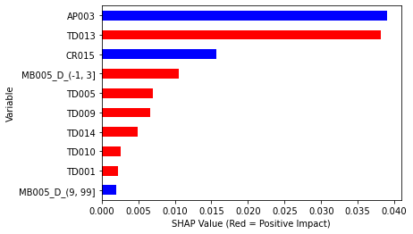

```python
def ABS_SHAP_top(df_shap,df):
    #import matplotlib as plt
    # Make a copy of the input data
    shap_v = pd.DataFrame(df_shap)
    feature_list = df.columns
    shap_v.columns = feature_list
    df_v = df.copy().reset_index().drop('index',axis=1)

    # Determine the correlation in order to plot with different colors
    corr_list = list()
    for i in feature_list:
        b = np.corrcoef(shap_v[i],df_v[i])[1][0]
        corr_list.append(b)
    corr_df = pd.concat([pd.Series(feature_list),pd.Series(corr_list)],axis=1).fillna(0)
    # Make a data frame. Column 1 is the feature, and Column 2 is the correlation coefficient
    corr_df.columns  = ['Variable','Corr']
    corr_df['Sign'] = np.where(corr_df['Corr']>0,'red','blue')

    # Plot it
    shap_abs = np.abs(shap_v)
    k=pd.DataFrame(shap_abs.mean()).reset_index()
    k.columns = ['Variable','SHAP_abs']
    k2 = k.merge(corr_df,left_on = 'Variable',right_on='Variable',how='inner')
    k2 = k2.sort_values(by='SHAP_abs',ascending = True).iloc[-10:,:]
    colorlist = k2['Sign']
    ax = k2.plot.barh(x='Variable',y='SHAP_abs',color = colorlist, figsize=(6,4),legend=False)
    ax.set_xlabel("SHAP Value (Red = Positive Impact)")

ABS_SHAP_top(shap_values,X_train)
```

#### Interpretation:

- AP003 shows a negative relationship with the target variable
- TD013 shows a positive relationship with the target variable
- CR015 shows a negative relationship with the target variable
- MB005*D*(-1,3] shows a positive relationship with the target variable
- TD005 / TD009 / TD014 / TD010 / TD001 all show positive relationship with the target variable
- MB005*D*(9,99] shows a negative relationship with the target variable

#### The dependence plot - Global Interpretability

A partial dependence plot shows the marginal effect of one or two features on the predicted outcome of a machine learning model. It tells whether the relationship between the target and a feature is linear, monotonic or more complex. It also tells interaction between features.

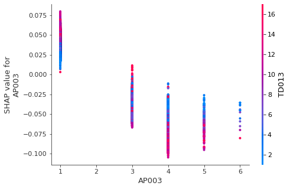

```python
shap.dependence_plot('AP003', shap_values, X_train)
```

#### Interpretation:

The above plot shows there might be a linear and negative trend between “AP003” and the target variable, and “AP003” interacts with “TD013” frequently. Also we can interpret that, when AP003 is 1, the impact is positive. Other than that, the impact is more negative.

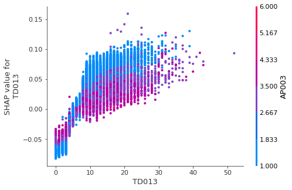

```python
shap.dependence_plot('TD013', shap_values, X_train)
```

#### Interpretation:

The above plot shows there is an approximately linear and positive trend between “TD013” and the target variable, and “TD013” interacts with “AP003” frequently.

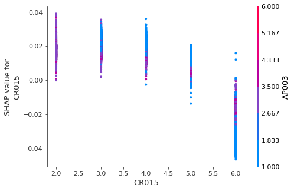

```python
shap.dependence_plot('CR015', shap_values, X_train)
```

#### Interpretation:

The above plot shows there might be a linear and negative trend between “CR015” and the target variable, and “CR015” interacts with “AP003” frequently.

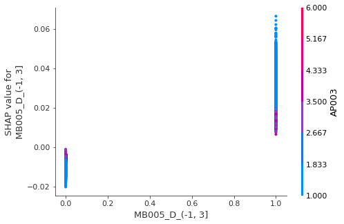

```python
shap.dependence_plot('MB005_D_(-1, 3]', shap_values, X_train)
```

#### Interpretation:

The above plot shows that when MB005 is in the category of (0-3), the impact is positive to the target variable, and when MB005 is not in the category of (0-3), the impact is negative to the target variable. “MB005*D*(-1, 3]” also interacts with “AP003” frequently and the interaction with "AP003" is inverted between 1 or 0.

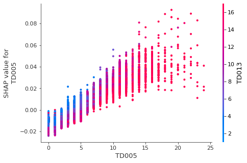

```python
shap.dependence_plot('TD005', shap_values, X_train)
```

#### Interpretation:

The above plot shows there is an approximately linear and positive trend between “TD005” and the target variable, and “TD005” interacts with “TD013” frequently. High TD005 might be correlated to high TD013.

#### The force_plot for 4 individual observations - Local Interpretability

Random select some observations and interpret the features impact for individual observations.

```python
# Create random observations
X_output = X_test.copy()
X_output.loc[:,'predict'] = np.round(model.predict(X_output),2)

random_picks = np.arange(1,500,50)
S = X_output.iloc[random_picks]
S
```

|  | TD013 | AP003 | TD009 | TD005 | CR015 | TD014 | TD010 | TD001 | MB007_360 | MB007_4G | ... | MB007_ZTE | MB007_ZUK | MB007_ZUOKU | MB005_D_(-1, 3] | MB005_D_(3, 4] | MB005_D_(4, 6] | MB005_D_(6, 9] | MB005_D_(9, 99] | MB005_D_NoData | predict |
| --- | --- | --- | --- | --- | --- | --- | --- | --- | --- | --- | --- | --- | --- | --- | --- | --- | --- | --- | --- | --- | --- |
| 3509 | 9 | 3 | 7 | 5 | 4 | 1 | 1 | 2 | 0 | 0 | ... | 0 | 0 | 0.0 | 1 | 0 | 0 | 0 | 0 | 0 | 0.20 |
| 5668 | 5 | 1 | 5 | 3 | 5 | 1 | 1 | 1 | 0 | 0 | ... | 0 | 0 | 0.0 | 0 | 0 | 0 | 0 | 1 | 0 | 0.21 |
| 55849 | 5 | 1 | 5 | 5 | 6 | 1 | 1 | 5 | 0 | 0 | ... | 0 | 0 | 0.0 | 0 | 0 | 0 | 0 | 1 | 0 | 0.16 |
| 29484 | 12 | 3 | 5 | 5 | 6 | 5 | 2 | 2 | 0 | 0 | ... | 0 | 0 | 0.0 | 0 | 0 | 1 | 0 | 0 | 0 | 0.19 |
| 17237 | 1 | 1 | 0 | 0 | 5 | 0 | 0 | 0 | 0 | 0 | ... | 0 | 0 | 0.0 | 0 | 0 | 0 | 1 | 0 | 0 | 0.16 |
| 31155 | 12 | 3 | 12 | 8 | 6 | 3 | 3 | 6 | 0 | 0 | ... | 0 | 0 | 0.0 | 0 | 1 | 0 | 0 | 0 | 0 | 0.21 |
| 53868 | 11 | 4 | 11 | 6 | 6 | 5 | 4 | 3 | 0 | 0 | ... | 0 | 0 | 0.0 | 0 | 0 | 0 | 1 | 0 | 0 | 0.14 |
| 74040 | 5 | 1 | 5 | 5 | 5 | 0 | 0 | 0 | 0 | 0 | ... | 0 | 0 | 0.0 | 0 | 0 | 0 | 1 | 0 | 0 | 0.23 |
| 18173 | 5 | 1 | 3 | 0 | 5 | 0 | 0 | 0 | 0 | 0 | ... | 0 | 0 | 0.0 | 0 | 0 | 0 | 1 | 0 | 0 | 0.20 |
| 29732 | 1 | 3 | 0 | 0 | 5 | 2 | 0 | 0 | 0 | 0 | ... | 0 | 0 | 0.0 | 1 | 0 | 0 | 0 | 0 | 0 | 0.09 |

10 rows × 122 columns

```python
# Average values of the top predictors
X_train.mean().head()
```

```
TD013    6.823188
AP003    2.013187
TD009    5.422781
TD005    3.602359
CR015    4.922906
dtype: float64
```

```python
shap.initjs()
```

```python
def shap_plot(j):
    explainerModel = shap.TreeExplainer(model)
    shap_values_Model = explainerModel.shap_values(S)
    p = shap.force_plot(explainerModel.expected_value, shap_values_Model[j], S.iloc[[j]])
    return(p)
```

##### Break the shap_plot in great details:

First observation plot

```python
shap_plot(0)
```

#### Interpretation:

- AP003: has a negative impact on the target variable (loan_default). The AP003 value of the observation is 3 which is higher than the average value 2.01. So it pushes the prediction to the left.
- TD013: has a positive impact on the target variable (loan_default). The TD013 value of the observation is 9 which is higher than the average value 6.82. So it drives the prediction to the right.
- MB005*D*(-1,3]: has a positive impact on the target variable (loan_default). A higher than the averagae value (= 1 > 0.26) drives the prediction to the right.
- CR015: has a negative impact on the target variable (loan_default). A lower than the average value (=4 < 4.92) drives the prediction to the right.

Second observation plot

```python
shap_plot(1)
```

#### Interpretation:

- AP003: has a negative impact on the target variable (loan_default). The AP003 value of the observation is 1 which is lower than the average value 2.01. So it drives the prediction to the right.
- CR015: has a negative impact on the target variable (loan_default). A higher than the average value (=5 > 4.92) drives the prediction to the right.
- MB005*D*(-1,3]: has a positive impact on the target variable (loan_default). A lower than the averagae value (= 0 < 0.26) pushes the prediction to the left.
- TD013: has a positive impact on the target variable (loan_default). The TD013 value of the observation is 5 which is lower than the average value 6.82. So it pushes the prediction to the left.
- TD014: has a positive impact on the target variable (loan_default). The TD014 value of the observation is 1 which is lower than the average value 2.60. So it pushes the prediction to the left.

Third observation plot

```python
shap_plot(2)
```

#### Interpretation:

- CR015: has a negative impact on the target variable (loan_default). A higher than the average value (=6 > 4.92) pushes the prediction to the left.
- TD013: has a positive impact on the target variable (loan_default). The TD013 value of the observation is 5 which is lower than the average value 6.82. So it pushes the prediction to the left.
- MB005*D*(-1,3]: has a positive impact on the target variable (loan_default). A lower than the averagae value (= 0 < 0.26) pushes the prediction to the left.
- AP003: has a negative impact on the target variable (loan_default). The AP003 value of the observation is 1 which is lower than the average value 2.01. So it drives the prediction to the right.
- TD001: has a positive impact on the target variable (loan_default). A higher than the average value (=5 > 1.99) drives the prediction to the right.

Fourth observation plot

```python
shap_plot(4)
```

#### Interpretation:

- AP003: has a negative impact on the target variable (loan_default). The AP003 value of the observation is 1 which is lower than the average value 2.01. So it drives the prediction to the right.
- TD013: has a positive impact on the target variable (loan_default). The TD013 value of the observation is 1 which is lower than the average value 6.82. So it pushes the prediction to the left.
- TD005: has a positive impact on the target variable (loan_default). A lower than the average value (=0 < 3.60) pushes the prediction to the left.
- MB005*D*(-1,3]: has a positive impact on the target variable (loan_default). A lower than the averagae value (= 0 < 0.26) pushes the prediction to the left.
- CR015: has a negative impact on the target variable (loan_default). A higher than the average value (=5 > 4.92) drives the prediction to the right.
- MB007_WEB: has a negative impact on the target variable (loan_default). A lower than the average value (=0 < 0.54) drives the prediction to the right.

## Summary

The main objective of the assignment is to learn and explain the model using SHAP value.

- Pick top 10 variables from H20 Random Forest Model. Prepare the data (using variable transformation, get dummies) to fit the data with SKlearn Random Forest Model.
- Then calculate SHAP values and interpret the model with SHAP value and relevent graphs. Each feature has a shap value contributing to the prediction. The shap value of a feature can be positive or negative.
- Summary plot shows global interpretability. For the top three variables: AP003 shows a negative relationship with the target variable, TD013 shows a positive relationship with the target variable, and CR015 shows a negative relationship with the target variable.
- Dependency plot shows the marginal effect of one or two features on the predicted outcome of a machine learning model, also global interpretability.
- Force plot shows local interpretability for each inidividual data observation. If a feature is positively correlated to the target, a value higher than its own average will contribute positively to the prediction. If a feature is negatively correlated to the target, a value higher than its own average will contribute negatively to the prediction.